# Random Forest - Bank Customers’ Perceptions

## Random Forest- What is it?

**Random Forest is a machine learning algorithm based on the idea of combining many simple models to obtain a more robust result**. Specifically, it builds multiple decision trees (a “forest”) and aggregates their outputs to produce more stable and accurate predictions.

**In market research, Random Forest can be applied to both regression and classification problems, such as predicting satisfaction, recommendation, or churn.** It is also used in combination with cluster analysis, either to explain segment membership or to identify the key variables that differentiate segments. By handling complex, non-linear relationships, Random Forest complements traditional exploratory techniques and supports more robust, data-driven decision making.

## Dataset and Survey Example

The data used in this example are purely synthetic and serve illustrative purposes only.

## Segmentation case

For the following example, we are going to use a formerly calculated 6 cluster solution based on k-means clustering:

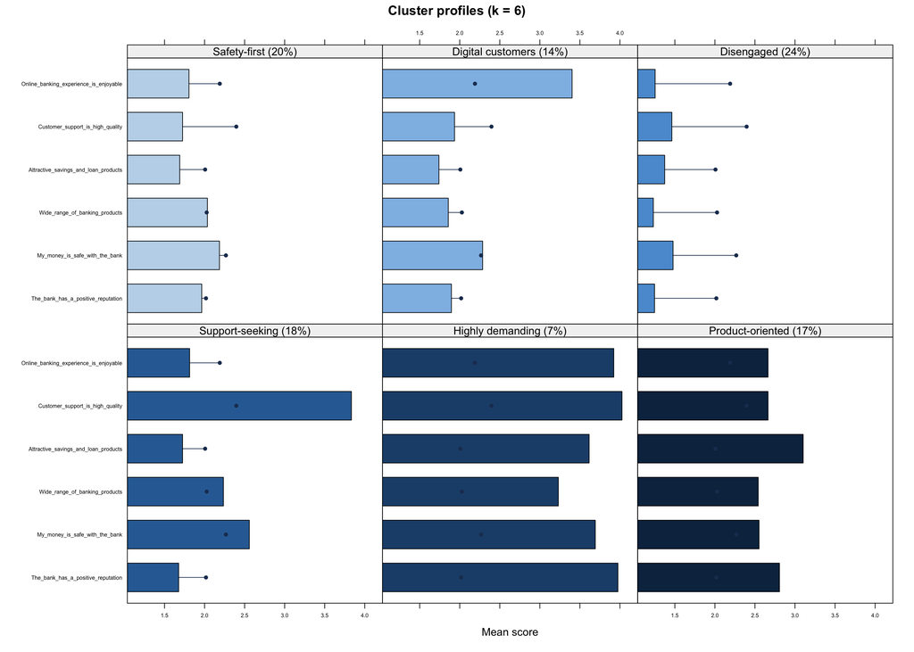

## Random Forest Classification

**In this section, the confusion matrix is used to examine** **how well the identified customer segments can be distinguished from one another**. Rather than evaluating prediction accuracy in a strict sense, the goal is to understand whether the clusters represent **clearly differentiated profiles** or whether some degree of overlap exists between them.

The matrix is read by comparing **rows and columns**. Each row represents the **true segment** a customer belongs to, while each column represents the **segment predicted by the model**. Values along the diagonal indicate customers who are correctly classified within their original segment, whereas values outside the diagonal show cases where customers are confused with another segment. For each cluster, the classification error indicates the share of customers that are not clearly distinguished from other groups.

Confusion Matrix

Random Forest classification of cluster membership

| Actual segment | Safety-first | Digital customers | Disengaged | Support-seeking | Highly demanding | Product-oriented | class.error |
| --- | --- | --- | --- | --- | --- | --- | --- |
| Safety-first | 105 | 0 | 5 | 1 | 0 | 2 | 0.07079646 |
| Digital customers | 0 | 71 | 0 | 0 | 0 | 6 | 0.07792208 |
| Disengaged | 2 | 1 | 130 | 1 | 0 | 0 | 0.02985075 |
| Support-seeking | 0 | 2 | 1 | 95 | 1 | 3 | 0.06862745 |
| Highly demanding | 0 | 0 | 0 | 1 | 33 | 5 | 0.15384615 |
| Product-oriented | 4 | 7 | 1 | 6 | 1 | 79 | 0.19387755 |

**The Adjusted Rand Index (ARI)** quantifies the agreement between two groupings while correcting for chance, with values closer to 1 indicating stronger agreement.

```
[1] 0.832152
```

We got Adjusted Rand Index (ARI = 0.83), indicating a high level of consistency between both approaches and supporting the robustness of the segmentation.

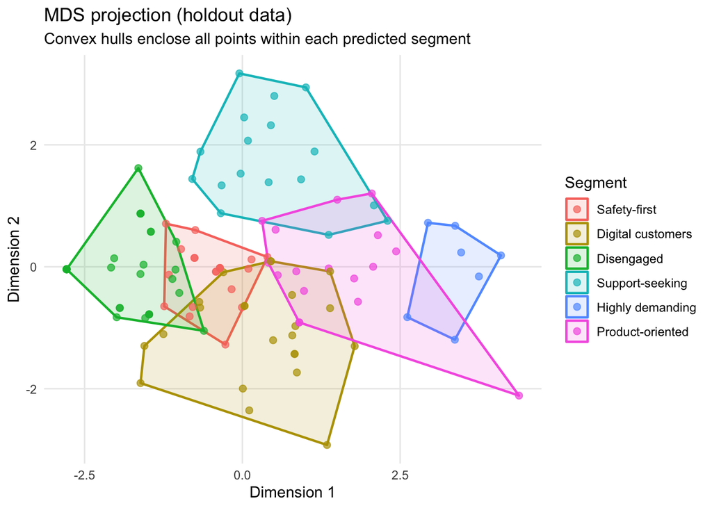

**The chart shows a two-dimensional MDS projection of customers in the holdout sample, coloured according to the segment predicted by the Random Forest model.** Each point represents a customer, while the shaded areas indicate the outer boundaries of each segment. The visualization highlights how some segments are clearly separated, while others partially overlap, reflecting natural similarities between certain customer profiles rather than sharp, artificial boundaries.

## Random Forest Variable Importance

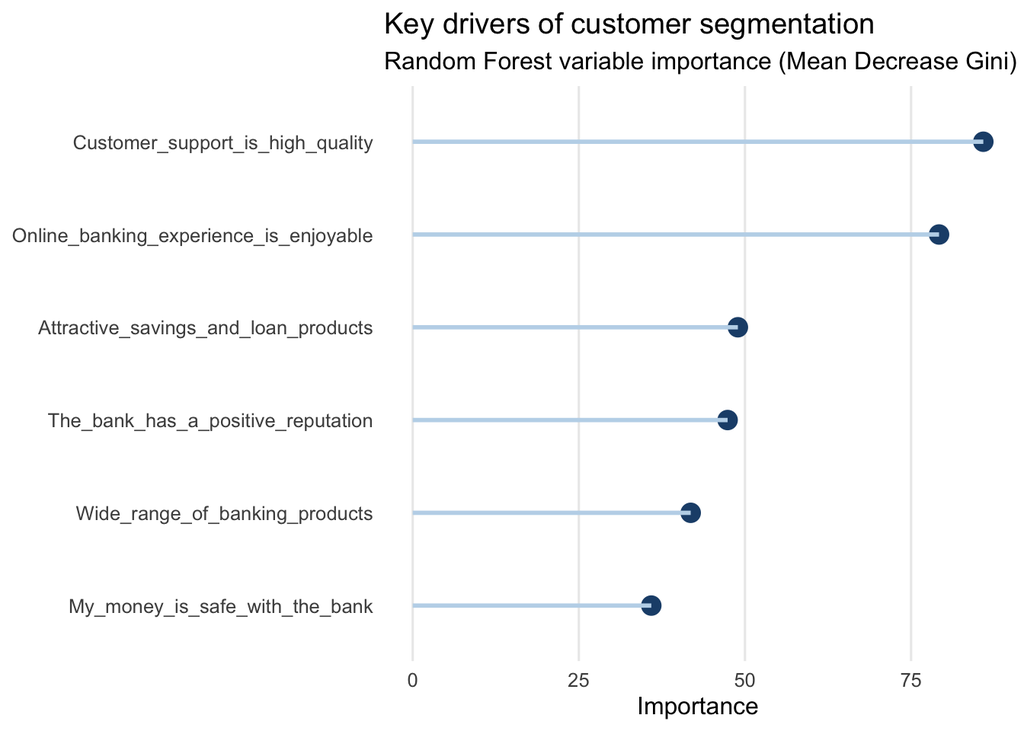

**The chart shows the relative importance of each variable in distinguishing between customer segments, based on the Random Forest model.** Each point represents a variable, with higher values indicating a stronger contribution to separating customers into different segments. Variables appearing at the top of the chart play a more influential role in the segmentation, while those lower down contribute less to differentiating customer profiles.

**From a decision-making perspective, the results suggest that not all attributes contribute equally to differentiating customer segments.** Variables such as **high-quality customer support** and an **enjoyable online banking experience** emerge as key drivers, indicating that improvements in service quality and digital experience are likely to have the greatest impact on how customers are segmented. In contrast, attributes like **perceived safety of money** or a **wide range of banking products** show relatively low importance, suggesting they function as baseline expectations rather than sources of differentiation. For strategic planning, this implies that banks should prioritize investments in customer support and digital channels to create meaningful differentiation, while maintaining—rather than over-investing in—hygiene factors such as safety and product breadth.

We now explore importance of variables segment by segment:

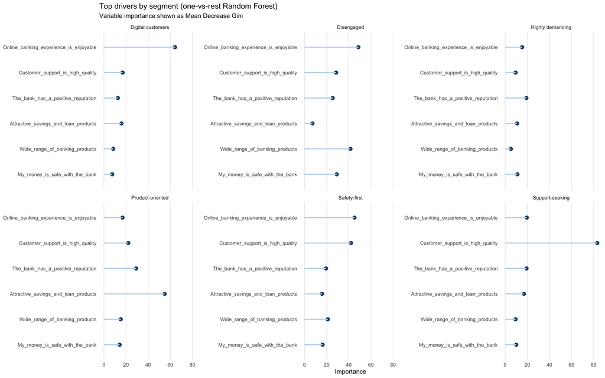

**The segment-level variable importance charts show which factors are most effective at distinguishing each segment from the rest of the customer base.** For each segment, variables with higher importance values represent the attributes that most strongly define its uniqueness relative to other groups. These drivers highlight where each segment differs most from the overall population, rather than simply reflecting average preference levels. From a decision-making perspective, this enables more targeted strategies by identifying the specific levers that can be used to address, retain, or reposition customers within each segment.